#### "No other similar published works for linear regression found with same dataset"

# Name of Project : Marketing Analysis for New Game

# Pranav Bhagat : 989352898

# 1. Objective

Activision are planning on developing a new game. They want to study the market before developing the game to know about the expected response the game recieves. They want to confirm that before the game goes into development, the game will be widely recieved by users as well as critics. They also want to know the potential rating the game could receive from Critics as well as Users based on the fact that it would fall in the Action Adventure genre.

Activision want us to study the sales of popular games and give them an estimate of how much of sale to expect globally as well as in North America and Europe-Japan. They would also like to They would also like for us to find out how much potential rating the game would receive as critic and User score.

We have been provided with a dataset which contains data about sales of various top games till 2016. The dataset contains columns such as NAme of the game, year of Release, Critic Score, USer Score, Total Sales, North America Sales, Europe Sales and so on. It also has details about the Platform and Genre which will helpus in our analysis.

```python
import pandas as pd
import numpy as np
import matplotlib.pyplot as plt
```

```python
d = pd.read_csv("C:/Python/VGS.csv")
```

# 2. Data Exploration

```python
d.head(10)
```

|  | Name | Platform | Year_of_Release | Genre | Publisher | NA_Sales | EU_Sales | JP_Sales | Other_Sales | Global_Sales | Critic_Score | Critic_Count | User_Score | User_Count | Developer | Rating |
| --- | --- | --- | --- | --- | --- | --- | --- | --- | --- | --- | --- | --- | --- | --- | --- | --- |
| 0 | Wii Sports | Wii | 2006.0 | Sports | Nintendo | 41.36 | 28.96 | 3.77 | 8.45 | 82.53 | 76.0 | 51.0 | 8 | 322.0 | Nintendo | E |
| 1 | Super Mario Bros. | NES | 1985.0 | Platform | Nintendo | 29.08 | 3.58 | 6.81 | 0.77 | 40.24 | NaN | NaN | NaN | NaN | NaN | NaN |
| 2 | Mario Kart Wii | Wii | 2008.0 | Racing | Nintendo | 15.68 | 12.76 | 3.79 | 3.29 | 35.52 | 82.0 | 73.0 | 8.3 | 709.0 | Nintendo | E |
| 3 | Wii Sports Resort | Wii | 2009.0 | Sports | Nintendo | 15.61 | 10.93 | 3.28 | 2.95 | 32.77 | 80.0 | 73.0 | 8 | 192.0 | Nintendo | E |
| 4 | Pokemon Red/Pokemon Blue | GB | 1996.0 | Role-Playing | Nintendo | 11.27 | 8.89 | 10.22 | 1.00 | 31.37 | NaN | NaN | NaN | NaN | NaN | NaN |
| 5 | Tetris | GB | 1989.0 | Puzzle | Nintendo | 23.20 | 2.26 | 4.22 | 0.58 | 30.26 | NaN | NaN | NaN | NaN | NaN | NaN |
| 6 | New Super Mario Bros. | DS | 2006.0 | Platform | Nintendo | 11.28 | 9.14 | 6.50 | 2.88 | 29.80 | 89.0 | 65.0 | 8.5 | 431.0 | Nintendo | E |
| 7 | Wii Play | Wii | 2006.0 | Misc | Nintendo | 13.96 | 9.18 | 2.93 | 2.84 | 28.92 | 58.0 | 41.0 | 6.6 | 129.0 | Nintendo | E |
| 8 | New Super Mario Bros. Wii | Wii | 2009.0 | Platform | Nintendo | 14.44 | 6.94 | 4.70 | 2.24 | 28.32 | 87.0 | 80.0 | 8.4 | 594.0 | Nintendo | E |
| 9 | Duck Hunt | NES | 1984.0 | Shooter | Nintendo | 26.93 | 0.63 | 0.28 | 0.47 | 28.31 | NaN | NaN | NaN | NaN | NaN | NaN |

Here we have displayed top 10 rows of the dataset using head

```python
d.count()
```

```
Name               9997
Platform           9998
Year_of_Release    9840
Genre              9997
Publisher          9968
NA_Sales           9998
EU_Sales           9998
JP_Sales           9998
Other_Sales        9998
Global_Sales       9998
Critic_Score       5702
Critic_Count       5702
User_Score         6676
User_Count         5559
Developer          6693
Rating             6656
dtype: int64
```

Here we see the number of filled rows in each column

```python
d['Critic_Score'].quantile([0,0.25,0.5,0.75,1])
```

```
0.00    19.0
0.25    63.0
0.50    73.0
0.75    81.0
1.00    98.0
Name: Critic_Score, dtype: float64
```

We have taken used the quantile command to display percentile for the Critic_Score column.

```python
len(d.columns)
```

```
16
```

The total number of columns is 16

```python
print(d.dtypes)
```

```
Name                object
Platform            object
Year_of_Release    float64
Genre               object
Publisher           object
NA_Sales           float64
EU_Sales           float64
JP_Sales           float64
Other_Sales        float64
Global_Sales       float64
Critic_Score       float64
Critic_Count       float64
User_Score          object
User_Count         float64
Developer           object
Rating              object
dtype: object
```

Here we have printed the type of each column.

# 3. Data Cleaning

```python
d = d[np.isfinite(d['Critic_Score'])]
d.head(10)
```

|  | Name | Platform | Year_of_Release | Genre | Publisher | NA_Sales | EU_Sales | JP_Sales | Other_Sales | Global_Sales | Critic_Score | Critic_Count | User_Score | User_Count | Developer | Rating |
| --- | --- | --- | --- | --- | --- | --- | --- | --- | --- | --- | --- | --- | --- | --- | --- | --- |
| 0 | Wii Sports | Wii | 2006.0 | Sports | Nintendo | 41.36 | 28.96 | 3.77 | 8.45 | 82.53 | 76.0 | 51.0 | 8 | 322.0 | Nintendo | E |
| 2 | Mario Kart Wii | Wii | 2008.0 | Racing | Nintendo | 15.68 | 12.76 | 3.79 | 3.29 | 35.52 | 82.0 | 73.0 | 8.3 | 709.0 | Nintendo | E |
| 3 | Wii Sports Resort | Wii | 2009.0 | Sports | Nintendo | 15.61 | 10.93 | 3.28 | 2.95 | 32.77 | 80.0 | 73.0 | 8 | 192.0 | Nintendo | E |
| 6 | New Super Mario Bros. | DS | 2006.0 | Platform | Nintendo | 11.28 | 9.14 | 6.50 | 2.88 | 29.80 | 89.0 | 65.0 | 8.5 | 431.0 | Nintendo | E |
| 7 | Wii Play | Wii | 2006.0 | Misc | Nintendo | 13.96 | 9.18 | 2.93 | 2.84 | 28.92 | 58.0 | 41.0 | 6.6 | 129.0 | Nintendo | E |
| 8 | New Super Mario Bros. Wii | Wii | 2009.0 | Platform | Nintendo | 14.44 | 6.94 | 4.70 | 2.24 | 28.32 | 87.0 | 80.0 | 8.4 | 594.0 | Nintendo | E |
| 11 | Mario Kart DS | DS | 2005.0 | Racing | Nintendo | 9.71 | 7.47 | 4.13 | 1.90 | 23.21 | 91.0 | 64.0 | 8.6 | 464.0 | Nintendo | E |
| 13 | Wii Fit | Wii | 2007.0 | Sports | Nintendo | 8.92 | 8.03 | 3.60 | 2.15 | 22.70 | 80.0 | 63.0 | 7.7 | 146.0 | Nintendo | E |
| 14 | Kinect Adventures! | X360 | 2010.0 | Misc | Microsoft Game Studios | 15.00 | 4.89 | 0.24 | 1.69 | 21.81 | 61.0 | 45.0 | 6.3 | 106.0 | Good Science Studio | E |
| 15 | Wii Fit Plus | Wii | 2009.0 | Sports | Nintendo | 9.01 | 8.49 | 2.53 | 1.77 | 21.79 | 80.0 | 33.0 | 7.4 | 52.0 | Nintendo | E |

```python
d1 = d.dropna()
```

We removed the rows with NaN values which would be helpful for our analysis.

```python
map = {'Action':0, 'Adventure':1,'Fighting':2, 'Misc':3, 'Platform':4, 'Puzzle':5, 'Racing':6, 'Role-Playing':7, 'Shooter':8, 'Simulation':9, 'Sports':10, 'Strategy':11}
d2 = d1.applymap(lambda s: map.get(s) if s in map else s)
```

```python
d2.head(5)
```

|  | Name | Platform | Year_of_Release | Genre | Publisher | NA_Sales | EU_Sales | JP_Sales | Other_Sales | Global_Sales | Critic_Score | Critic_Count | User_Score | User_Count | Developer | Rating |
| --- | --- | --- | --- | --- | --- | --- | --- | --- | --- | --- | --- | --- | --- | --- | --- | --- |
| 0 | Wii Sports | Wii | 2006.0 | 10 | Nintendo | 41.36 | 28.96 | 3.77 | 8.45 | 82.53 | 76.0 | 51.0 | 8 | 322.0 | Nintendo | E |
| 2 | Mario Kart Wii | Wii | 2008.0 | 6 | Nintendo | 15.68 | 12.76 | 3.79 | 3.29 | 35.52 | 82.0 | 73.0 | 8.3 | 709.0 | Nintendo | E |
| 3 | Wii Sports Resort | Wii | 2009.0 | 10 | Nintendo | 15.61 | 10.93 | 3.28 | 2.95 | 32.77 | 80.0 | 73.0 | 8 | 192.0 | Nintendo | E |
| 6 | New Super Mario Bros. | DS | 2006.0 | 4 | Nintendo | 11.28 | 9.14 | 6.50 | 2.88 | 29.80 | 89.0 | 65.0 | 8.5 | 431.0 | Nintendo | E |
| 7 | Wii Play | Wii | 2006.0 | 3 | Nintendo | 13.96 | 9.18 | 2.93 | 2.84 | 28.92 | 58.0 | 41.0 | 6.6 | 129.0 | Nintendo | E |

We changed the Genre column which is a string into an integer column for our analysis purposes.

# 4. Adaptation

```python
d2['Critic_Rating'] = d[['Critic_Score', 'Critic_Count']].mean(axis=1)
d2.head(5)
```

|  | Name | Platform | Year_of_Release | Genre | Publisher | NA_Sales | EU_Sales | JP_Sales | Other_Sales | Global_Sales | Critic_Score | Critic_Count | User_Score | User_Count | Developer | Rating | Critic_Rating |
| --- | --- | --- | --- | --- | --- | --- | --- | --- | --- | --- | --- | --- | --- | --- | --- | --- | --- |
| 0 | Wii Sports | Wii | 2006.0 | 10 | Nintendo | 41.36 | 28.96 | 3.77 | 8.45 | 82.53 | 76.0 | 51.0 | 8 | 322.0 | Nintendo | E | 63.5 |
| 2 | Mario Kart Wii | Wii | 2008.0 | 6 | Nintendo | 15.68 | 12.76 | 3.79 | 3.29 | 35.52 | 82.0 | 73.0 | 8.3 | 709.0 | Nintendo | E | 77.5 |
| 3 | Wii Sports Resort | Wii | 2009.0 | 10 | Nintendo | 15.61 | 10.93 | 3.28 | 2.95 | 32.77 | 80.0 | 73.0 | 8 | 192.0 | Nintendo | E | 76.5 |
| 6 | New Super Mario Bros. | DS | 2006.0 | 4 | Nintendo | 11.28 | 9.14 | 6.50 | 2.88 | 29.80 | 89.0 | 65.0 | 8.5 | 431.0 | Nintendo | E | 77.0 |
| 7 | Wii Play | Wii | 2006.0 | 3 | Nintendo | 13.96 | 9.18 | 2.93 | 2.84 | 28.92 | 58.0 | 41.0 | 6.6 | 129.0 | Nintendo | E | 49.5 |

We created a new column, Critic Rating which is the average of Critic_Score and Critic_count. This column would be helpful to us in our analysis.

```python
d2['EU_JP'] = d2['EU_Sales'] + d2['JP_Sales']
d2.head(5)
```

|  | Name | Platform | Year_of_Release | Genre | Publisher | NA_Sales | EU_Sales | JP_Sales | Other_Sales | Global_Sales | Critic_Score | Critic_Count | User_Score | User_Count | Developer | Rating | Critic_Rating | EU_JP |
| --- | --- | --- | --- | --- | --- | --- | --- | --- | --- | --- | --- | --- | --- | --- | --- | --- | --- | --- |
| 0 | Wii Sports | Wii | 2006.0 | 10 | Nintendo | 41.36 | 28.96 | 3.77 | 8.45 | 82.53 | 76.0 | 51.0 | 8 | 322.0 | Nintendo | E | 63.5 | 32.73 |
| 2 | Mario Kart Wii | Wii | 2008.0 | 6 | Nintendo | 15.68 | 12.76 | 3.79 | 3.29 | 35.52 | 82.0 | 73.0 | 8.3 | 709.0 | Nintendo | E | 77.5 | 16.55 |
| 3 | Wii Sports Resort | Wii | 2009.0 | 10 | Nintendo | 15.61 | 10.93 | 3.28 | 2.95 | 32.77 | 80.0 | 73.0 | 8 | 192.0 | Nintendo | E | 76.5 | 14.21 |
| 6 | New Super Mario Bros. | DS | 2006.0 | 4 | Nintendo | 11.28 | 9.14 | 6.50 | 2.88 | 29.80 | 89.0 | 65.0 | 8.5 | 431.0 | Nintendo | E | 77.0 | 15.64 |
| 7 | Wii Play | Wii | 2006.0 | 3 | Nintendo | 13.96 | 9.18 | 2.93 | 2.84 | 28.92 | 58.0 | 41.0 | 6.6 | 129.0 | Nintendo | E | 49.5 | 12.11 |

# 5. Descriptive Visualization

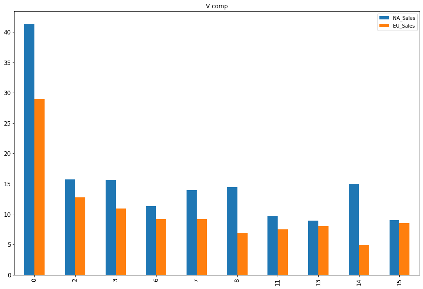

```python
P1 = d.head(10)
ax = P1[['NA_Sales','EU_Sales']].plot(kind='bar', title ="V comp", figsize=(15, 10), legend=True, fontsize=12)
ax
```

Here we have displayed the comparision in sales of the top 10 games in North America and Europe. The Sales in North America is higher for all the games.

```python
P2 = pd.DataFrame(P1, columns = ['Name', 'Global_Sales'])
P3 = P2.set_index('Name')
```

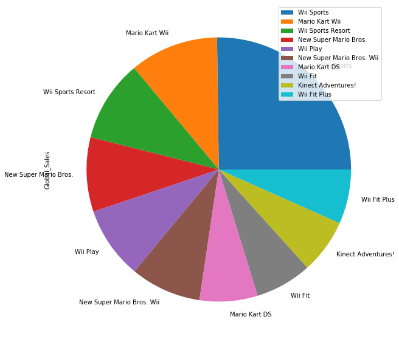

```python
plot = P3.plot.pie(y='Global_Sales', figsize=(10, 10))
```

Here we have displayed the global sales of the top 10 games.

```
array([[<matplotlib.axes._subplots.AxesSubplot object at 0x00000258956FAFD0>]],
      dtype=object)
```

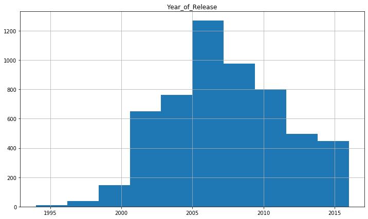

```python
d.hist(column = 'Year_of_Release', figsize = (12,7) )
```

From this histogram, we can say that maximum games were released in the year 2005.

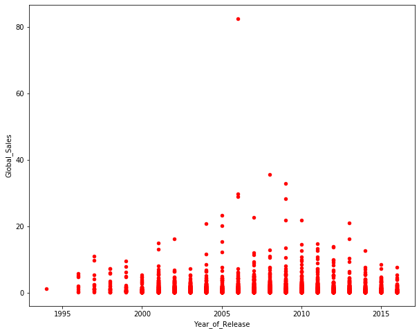

```python
d.plot(x ='Year_of_Release', y='Global_Sales', kind = 'scatter', figsize = (10,8), color = ['Red'])
```

# 6. Heirarchial Clustering

```python
df1 = d2[['Genre','NA_Sales', 'EU_JP']]
df2 = df1[:100]
df2.head(5)
```

|  | Genre | NA_Sales | EU_JP |
| --- | --- | --- | --- |
| 0 | 10 | 41.36 | 32.73 |
| 2 | 6 | 15.68 | 16.55 |
| 3 | 10 | 15.61 | 14.21 |
| 6 | 4 | 11.28 | 15.64 |
| 7 | 3 | 13.96 | 12.11 |

```python
df3 = d2[['Genre', 'EU_JP', 'NA_Sales']]
d4 = df3.head(100)
```

Here we created a dataframe with the required 3 columns.

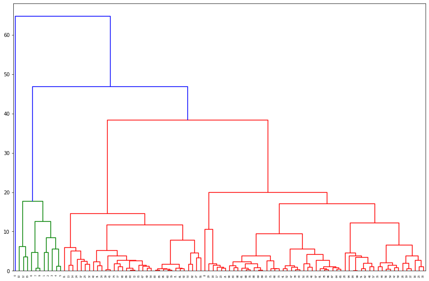

```python
import scipy.cluster.hierarchy as sch

plt.figure(figsize = (15,10))
dendrogram = sch.dendrogram(sch.linkage(d4, method='ward'))
```

Here we have printed the dendogram. From the dendogram we have taken a total of 5 clusters.

```python
from sklearn.cluster import AgglomerativeClustering

clus = AgglomerativeClustering(n_clusters=5, affinity='euclidean', linkage='ward')
clus.fit_predict(df2)
```

```
array([3, 0, 0, 0, 0, 0, 0, 0, 4, 0, 0, 1, 0, 1, 1, 0, 2, 4, 4, 2, 4, 4,
       2, 1, 1, 2, 2, 1, 2, 4, 2, 1, 1, 2, 1, 2, 2, 1, 2, 1, 1, 2, 2, 2,
       2, 1, 2, 2, 2, 1, 2, 2, 2, 1, 1, 1, 2, 2, 2, 2, 1, 2, 2, 1, 2, 2,
       2, 1, 2, 2, 1, 1, 1, 2, 1, 2, 2, 1, 2, 1, 2, 1, 1, 1, 2, 1, 1, 2,
       2, 2, 2, 2, 1, 1, 2, 1, 2, 2, 2, 2], dtype=int64)
```

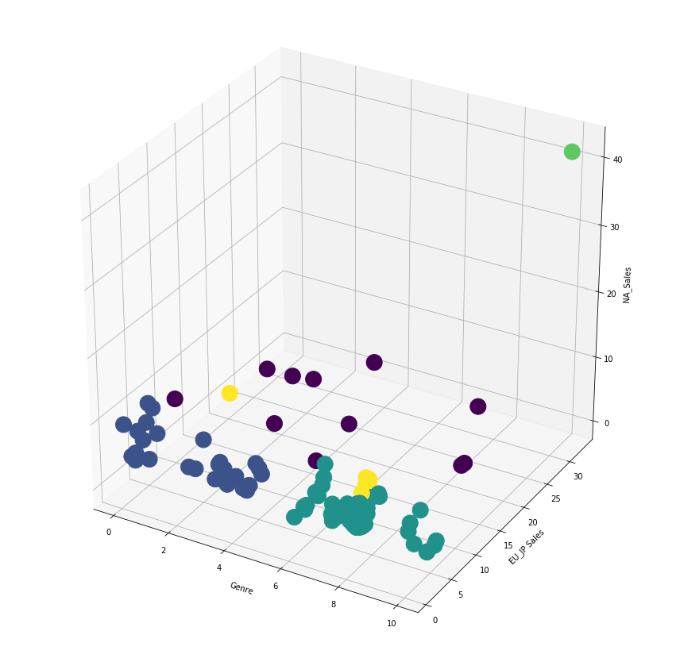

```python
from mpl_toolkits.mplot3d import Axes3D

fig = plt.figure()
fig = plt.figure(figsize=(15, 15))
ax = fig.add_subplot(111, projection='3d')

ax.scatter(xs = d4.Genre,ys = d4.EU_JP, zs = d4.NA_Sales, c = clus.labels_,
           s = 400, depthshade = False)
ax.set_xlabel('Genre')
ax.set_ylabel('EU_JP Sales')
ax.set_zlabel('NA_Sales')

plt.show()
```

Here we have carried out agglomorative clustering and plotted the cluster from the dataset that we have.

# Step by step K-Means

```python
dk1 = pd.DataFrame(d4, columns = ['Genre','EU_JP','NA_Sales'])
dk2 = dk1[:150]
df4 = dk2.dropna()
df4['Genre'] = df4['Genre'].astype(float)
df4.head(5)
```

|  | Genre | EU_JP | NA_Sales |
| --- | --- | --- | --- |
| 0 | 10.0 | 32.73 | 41.36 |
| 2 | 6.0 | 16.55 | 15.68 |
| 3 | 10.0 | 14.21 | 15.61 |
| 6 | 4.0 | 15.64 | 11.28 |
| 7 | 3.0 | 12.11 | 13.96 |

```python
from random import randint
centroid1 = np.array([randint(1, 28),randint(1, 28),randint(1, 28)])
centroid2 = np.array([randint(1, 28),randint(1, 28),randint(1, 28)])
centroid3 = np.array([randint(1, 28),randint(1, 28),randint(1, 28)])
print(centroid1,centroid2,centroid3)
```

```
[ 8 14 26] [4 5 5] [ 2 12 23]
```

Here we have generated randomcentroids using the randint function

```python
from sklearn import datasets
from sklearn.cluster import KMeans
import sklearn.metrics as sm
def kMeans(df4,centroid1,centroid2,centroid3):

    df4["Dist_C1"] = np.sqrt((df4.Genre - centroid1[0])**2 + (df4.EU_JP - centroid1[1])**2 + (df4.NA_Sales - centroid1[2])**2)
    df4["Dist_C2"] = np.sqrt((df4.Genre - centroid2[0])**2 + (df4.EU_JP - centroid2[1])**2 + (df4.NA_Sales - centroid2[2])**2)
    df4["Dist_C3"] = np.sqrt((df4.Genre - centroid3[0])**2 + (df4.EU_JP - centroid3[1])**2 + (df4.NA_Sales - centroid3[2])**2)

    #Clustering the datapoints according to the distance
    df4["Association"] = np.where((df4.Dist_C1 < df4.Dist_C2) &
                                  (df4.Dist_C1 < df4.Dist_C3), 1,
                                   np.where((df4.Dist_C2 < df4.Dist_C1) &
                                  (df4.Dist_C2 < df4.Dist_C3) , 2, 3))

    #caluclating the mean of new centroids with the associated datapoints
    centroid1 = df4[df4.Association == 1][["Genre", "EU_JP", "NA_Sales"]].mean()
    centroid2 = df4[df4.Association == 2][["Genre", "EU_JP", "NA_Sales"]].mean()
    centroid3 = df4[df4.Association == 3][["Genre", "EU_JP", "NA_Sales"]].mean()

    return (df4,centroid1,centroid2,centroid3)
```

```python
l= range(10)

for i in l:
    df4,x,y,z= kMeans(df4,centroid1,centroid2,centroid3)
    if centroid1[0] == x[0]:
        break
    else:
        centroid1 = x
        centroid2 = y
        centroid3 = z
        print(centroid1,centroid2,centroid3)

print ('Centroids = ')
print(centroid1,centroid2,centroid3)
```

[output not shown]

```python
group= df4.groupby('Association')
group.Association.count()
```

```
Association
1     1
2    90
3     9
Name: Association, dtype: int64
```

This shows how many points are associated to which centroid.

# SkLearn cluster

```python
from sklearn import datasets
from sklearn.cluster import KMeans

model = KMeans(n_clusters=4)
model.fit(d4)
```

```
KMeans(algorithm='auto', copy_x=True, init='k-means++', max_iter=300,
       n_clusters=4, n_init=10, n_jobs=None, precompute_distances='auto',
       random_state=None, tol=0.0001, verbose=0)
```

Here we have used the sklearn library to create clusters.

```python
model.labels_
```

```
array([2, 0, 0, 0, 0, 0, 0, 0, 0, 0, 1, 1, 0, 1, 1, 3, 3, 3, 3, 3, 3, 3,
       3, 1, 1, 3, 3, 1, 3, 3, 3, 1, 1, 3, 1, 3, 3, 1, 3, 1, 1, 3, 3, 3,
       3, 1, 3, 3, 3, 1, 3, 3, 3, 1, 1, 1, 3, 3, 3, 3, 1, 3, 3, 1, 3, 3,
       3, 1, 3, 3, 1, 1, 1, 3, 1, 3, 3, 1, 3, 1, 3, 1, 1, 1, 3, 1, 1, 3,
       3, 3, 3, 3, 1, 1, 3, 1, 3, 3, 3, 3])
```

```python
df5 = pd.concat([d4, pd.Series(model.labels_)], axis=1)
df5.columns = ['Genre','NA_Sales','EU_JP','Association']
```

```python
df6 = df5.groupby('Association')
df6.Association.count()
```

```
Association
0.0    10
1.0    35
2.0     1
3.0    54
Name: Association, dtype: int64
```

This shows how many points are associated to which cluster.